# R Meta

by S. M. Nielsen

# Meta-analysis and forest plot - published in Cochrane review (Cochrane style)

Let’s try to reproduce first meta-analysis and forest plot presented in the Cochrane review by [Leopoldino et al. (2019)](https://www.cochranelibrary.com/cdsr/doi/10.1002/14651858.CD013273/full), where the benefits and harms of paracetamol versus placebo for knee and hip osteoarthritis was investigated.

The forest plot shows the effect on pain (expressed on scale of 0 to 100) at immediate term (follow-up two weeks or less) or short term (follow-up more than two weeks but three months or less). Further details can be found in the article.

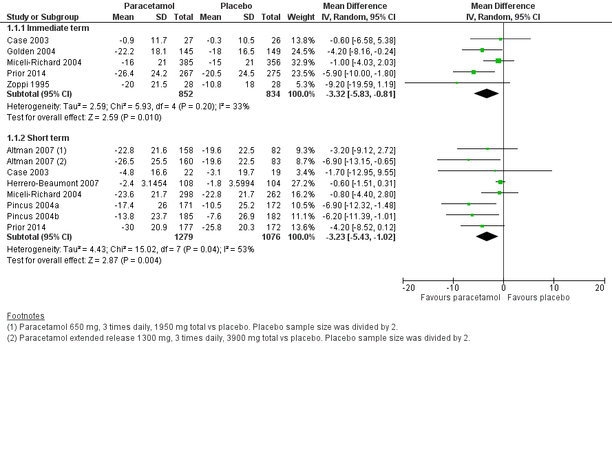

### Read in the data

To make it simple, all data needed for the figure is typed into R in this format. (Data can often be downloaded directly from Cochrane reviews with the option ‘Download statistical data’ and read using ‘Review Manager’, from which it can be copy-pasted to e.g. Excel)

```
##                    Study      Term Mean_I   SD_I N_I Mean_C   SD_C N_C
## 1              Case 2003 Immediate   -0.9   11.7  27   -0.3   10.5  26
## 2            Golden 2004 Immediate  -22.2   18.1 145    -18   16.5 149
## 3    Miceli-Richard 2004 Immediate    -16     21 385    -15     21 356
## 4             Prior 2014 Immediate  -26.4   24.2 267  -20.5   24.5 275
## 5             Zoppi 1995 Immediate    -20   21.5  28  -10.8     18  28
## 6        Altman 2007 (1)     Short  -22.8   21.6 158  -19.6   22.5  82
## 7        Altman 2007 (2)     Short  -26.5   25.5 160  -19.6   22.5  83
## 8              Case 2003     Short   -4.8   16.6  22   -3.1   19.7  19
## 9  Herrero-Beaumont 2007     Short   -2.4 3.1454 108   -1.8 3.5994 104
## 10   Miceli-Richard 2004     Short  -23.6   21.7 298  -22.8   21.7 262
## 11          Pincus 2004a     Short  -17.4     26 171  -10.5   25.2 172
## 12          Pincus 2004b     Short  -13.8   23.7 185   -7.6   26.9 182
## 13            Prior 2014     Short    -30   20.9 177  -25.8   20.3 172
```

Click on ‘CODE’ to see how the data is typed into R - use the same principle for your own data.

```r
Study <- c("Case 2003","Golden 2004","Miceli-Richard 2004","Prior 2014","Zoppi 1995","Altman 2007 (1)","Altman 2007 (2)","Case 2003","Herrero-Beaumont 2007","Miceli-Richard 2004","Pincus 2004a","Pincus 2004b","Prior 2014")

Term <- c("Immediate","Immediate","Immediate","Immediate","Immediate","Short","Short","Short","Short","Short","Short","Short","Short")

Mean_I <- c(-0.9,-22.2,-16,-26.4,-20,-22.8,-26.5,-4.8,-2.4,-23.6,-17.4,-13.8,-30)
SD_I <- c(11.7,18.1,21,24.2,21.5,21.6,25.5,16.6,3.1454,21.7,26,23.7,20.9)
N_I <- c(27,145,385,267,28,158,160,22,108,298,171,185,177)
Mean_C <- c(-0.3,-18,-15,-20.5,-10.8,-19.6,-19.6,-3.1,-1.8,-22.8,-10.5,-7.6,-25.8)
SD_C <- c(10.5,16.5,21,24.5,18,22.5,22.5,19.7,3.5994,21.7,25.2,26.9,20.3)
N_C <- c(26,149,356,275,28,82,83,19,104,262,172,182,172)


DATA <- as.data.frame(cbind(Study, Term, Mean_I, SD_I, N_I, Mean_C, SD_C, N_C))
DATA
```

For the analysis, you will need the package ‘metafor’.